Study report · Local-MCQ-Gen v1

# A benchmark of eight open-weight models writing dermatology board items.

1,920 generations. Two independent judges. One blueprint. Compiled from the dual-judge evaluation of the text-only canonical prompt, with inter-rater agreement and per-item disagreement triage.

**Compiled**  
21 April 2026 · 18:24 UTC  
**Corpus**  
1920 items · 8 generators · 2 judges · 1,908 paired scores

## Findings

Two pre-registered hypotheses fail under both judges. Medical fine-tuning — represented here by **MedGemma 27B** — yields clinically plausible stems but breaks single-best-answer integrity, with fatal-flaw rates between 18 % and 53 % depending on judge. Reasoning-distilled models (**DeepSeek-R1-Distill**, **Phi-4-reasoning**) rank bottom-third under both judges; their chain-of-thought style frequently contradicts the keyed answer in the explanation field.

Judges *agree* on perfect and broken items, and *disagree* on the middle tier. Pearson *r* = 0.68 on the weighted score; Cohen's κ = 0.46 on binary ready-to-use classification. Fifty items at highest inter-judge delta are queued for board-certified review.

### Dual-judge headline

01

## At a glance

Every item was independently scored by two judges on the full 10-criterion blinded rubric. Gemma-4-26B-A4B-it produced zero judgment failures; the Qwen-Claude judge returned twelve unrecoverable JSON decode errors, which are queued for human review.

Generator models

8

eight locally-served open-weight LLMs

Total items judged

1,920

120 objectives × 8 models × 2 seeds

Paired judgments

1,908

scored by both Gemma-26B & Qwen-Claude

Inter-judge r

0.68

Pearson on the 0–100 weighted score

Cohen's κ

0.46

binary ready-to-use classification

02

## Leaderboards, by judge.

Each judge scored the full 1,920-item corpus. The rankings below sort by mean weighted total score within judge; the top three are identical across judges. Columns use scientific-table conventions — decimal-aligned numerics, hairline row rules.

Judge A · Gemma 4 26B-A4B-it

### 1,920 scored · 0 failures

Judge A · Gemma-4-26B-A4B-it. Mean & rates computed over scored items only.

| # | Model | n | Mean | Ready ≥85 | Acc-safe | Fatal |
| --- | --- | --- | --- | --- | --- | --- |
| 1 | gemma-4-31b-it | 240 | 98.92 | 100.0% | 100.0% | 0.0% |
| 2 | gemma-4-26b-a4b-it | 240 | 97.77 | 97.9% | 96.2% | 3.8% |
| 3 | qwen3-6-35b-a3b | 240 | 95.79 | 93.3% | 93.3% | 6.7% |
| 4 | mistral-small-3-2-24b-instruct-2506 | 240 | 90.11 | 84.2% | 82.5% | 17.5% |
| 5 | llama-3-3-70b-instruct | 240 | 87.77 | 80.8% | 83.8% | 16.2% |
| 6 | phi-4-reasoning | 240 | 86.62 | 77.9% | 79.2% | 20.4% |
| 7 | medgemma-27b-text-it | 240 | 84.64 | 62.1% | 46.7% | 53.3% |
| 8 | deepseek-r1-distill-qwen-32b | 240 | 81.38 | 70.8% | 69.6% | 28.7% |

Judge B · Qwen 3.5 27B Claude-distill

### 1,908 scored · 12 failures

Judge B · Qwen-3.5-27B-Claude-distill. Mean & rates computed over scored items only.

| # | Model | n | Mean | Ready ≥85 | Acc-safe | Fatal |
| --- | --- | --- | --- | --- | --- | --- |
| 1 | gemma-4-31b-it | 240 | 99.45 | 100.0% | 100.0% | 0.0% |
| 2 | gemma-4-26b-a4b-it | 240 | 97.12 | 95.8% | 97.5% | 2.1% |
| 3 | qwen3-6-35b-a3b | 240 | 92.93 | 87.9% | 90.4% | 7.5% |
| 4 | mistral-small-3-2-24b-instruct-2506 | 235 | 84.69 | 69.8% | 77.0% | 18.3% |
| 5 | medgemma-27b-text-it | 239 | 83.83 | 72.0% | 78.2% | 18.4% |
| 6 | llama-3-3-70b-instruct | 238 | 81.16 | 65.1% | 71.4% | 26.1% |
| 7 | phi-4-reasoning | 239 | 78.94 | 62.8% | 68.6% | 26.4% |
| 8 | deepseek-r1-distill-qwen-32b | 237 | 71.55 | 49.4% | 57.4% | 36.7% |

03

## How much do the judges agree?

Enough to trust the ranking, not enough to trust any single item's weighted score as ground truth. Item-level Pearson *r* = 0.68 on the continuous score — the judges agree on extremes and diverge on middling items. Binary agreement on ready-to-use is 82 %; on fatal-flaw, 83 %.

| Metric | n | Pearson r | Spearman ρ | ICC(2,1) | Δ̄ (G−Q) | \|Δ̄\| |
| --- | --- | --- | --- | --- | --- | --- |
| Weighted total (0–100) | 1908 | 0.678 | 0.631 | 0.646 | 4.21 | 8.67 |

| Binary outcome | n | Cohen κ | Agreement | Gemma + | Qwen-C + |
| --- | --- | --- | --- | --- | --- |
| ready_to_use (>=85 & !fatal) | 1908 | 0.464 | 82.3% | 83.5% | 75.4% |
| fatal_flaw | 1908 | 0.426 | 83.4% | 18.2% | 16.9% |

**Per-criterion correlation (10 rubric dimensions)**

| Criterion | Pearson r | Spearman ρ | Ḡ | Q̄ | \|Δ̄\| |
| --- | --- | --- | --- | --- | --- |
| Explanation - distractors | 0.677 | 0.630 | 3.21 | 3.10 | 0.59 |
| Technical flaws / safety | 0.664 | 0.641 | 3.26 | 3.25 | 0.52 |
| Explanation - correct | 0.631 | 0.495 | 3.75 | 3.42 | 0.42 |
| Single-best-answer | 0.626 | 0.547 | 3.69 | 3.46 | 0.38 |
| Stem clarity | 0.623 | 0.521 | 3.78 | 3.67 | 0.26 |
| Dermatology specificity | 0.612 | 0.515 | 3.78 | 3.63 | 0.28 |
| Accuracy / key | 0.599 | 0.527 | 3.60 | 3.46 | 0.42 |
| Board authenticity | 0.587 | 0.521 | 3.74 | 3.64 | 0.28 |
| Difficulty / discrimination | 0.542 | 0.416 | 3.31 | 3.38 | 0.56 |
| Distractor quality | 0.496 | 0.467 | 3.77 | 3.28 | 0.55 |

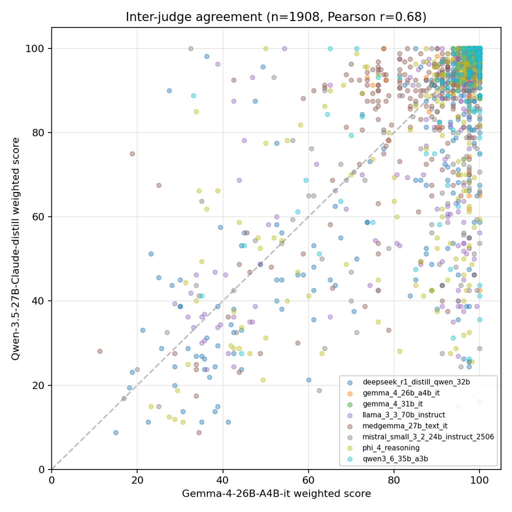

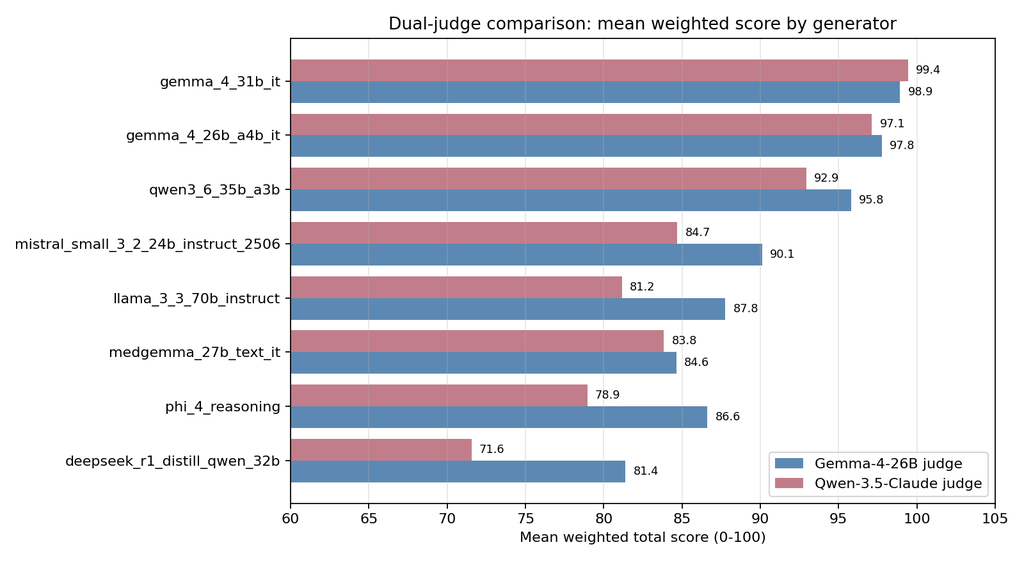

04

## The two outcomes that matter most.

Fatal flaws and accuracy-safe usable rate are the decision-relevant metrics. Fatal flaws are disqualifying (wrong key, multi-best-answer, insufficient stem, unsafe teaching). Accuracy-safe usable requires: no fatal flaw, `accuracy_key_correctness` ≥ 3, and weighted ≥ 70.

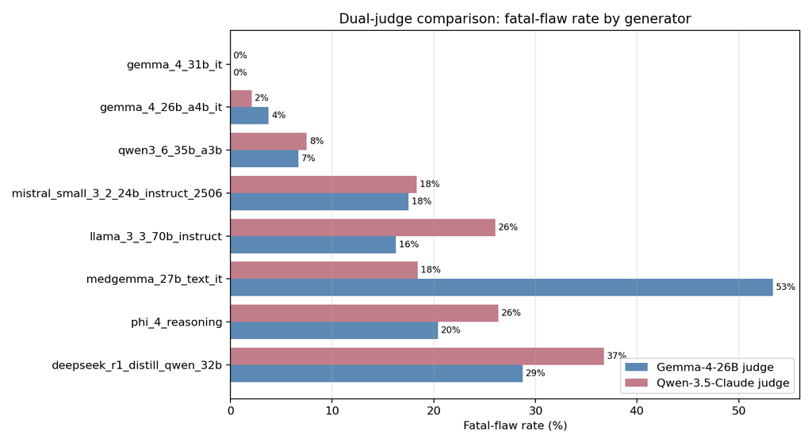

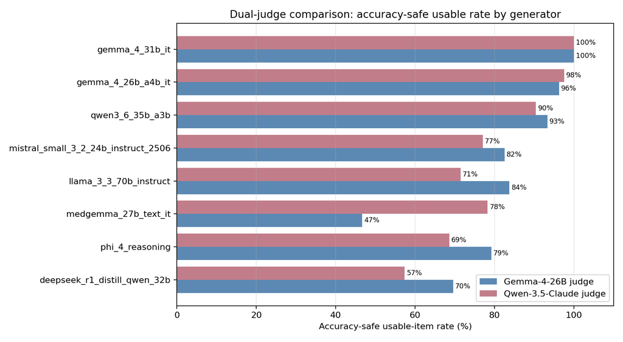

Fig. 4 · Accuracy-safe usable rate. This metric combines fatal-flaw-free, adequate accuracy, and reasonable weighted score — the fraction of items a residency program could actually use.

05

## Where the judges disagree most.

The fifty items below have the largest absolute Gemma − Qwen-Claude weighted-score gap. They represent the richest signal for human adjudication — cases where two competent rubric evaluators reach meaningfully different conclusions.

| Generator | Domain | Difficulty | Gemma | Qwen-C | \|Δ\| | Δ (G−Q) | Fatal G / Q |
| --- | --- | --- | --- | --- | --- | --- | --- |
| deepseek_r1_distill_qwen_32b | Dermatopathology | hard_board | 100.0 | 16.2 | 83.8 | +83.8 | · / ⚠ |
| phi_4_reasoning | Dermatopathology | hard_board | 98.8 | 17.5 | 81.2 | +81.2 | · / ⚠ |
| medgemma_27b_text_it | Medical Dermatology | standard_board | 95.0 | 15.0 | 80.0 | +80.0 | · / ⚠ |
| deepseek_r1_distill_qwen_32b | Medical Dermatology | standard_board | 97.5 | 24.4 | 73.1 | +73.1 | · / ⚠ |
| phi_4_reasoning | Dermatopathology | standard_board | 98.1 | 25.6 | 72.5 | +72.5 | · / ⚠ |
| mistral_small_3_2_24b_instruct_2506 | Pediatric Dermatology | standard_board | 97.5 | 25.6 | 71.9 | +71.9 | · / ⚠ |
| deepseek_r1_distill_qwen_32b | Dermatopathology | hard_board | 97.5 | 25.6 | 71.9 | +71.9 | · / ⚠ |
| mistral_small_3_2_24b_instruct_2506 | Pediatric Dermatology | standard_board | 95.6 | 24.4 | 71.2 | +71.2 | · / ⚠ |
| mistral_small_3_2_24b_instruct_2506 | Pediatric Dermatology | standard_board | 100.0 | 28.8 | 71.2 | +71.2 | · / ⚠ |
| qwen3_6_35b_a3b | Surgical Dermatology | hard_board | 97.5 | 26.2 | 71.2 | +71.2 | · / ⚠ |
| deepseek_r1_distill_qwen_32b | Dermatopathology | lower_edge_board | 96.2 | 26.2 | 70.0 | +70.0 | · / ⚠ |
| llama_3_3_70b_instruct | Dermatopathology | lower_edge_board | 95.0 | 26.9 | 68.1 | +68.1 | · / ⚠ |
| deepseek_r1_distill_qwen_32b | Medical Dermatology | lower_edge_board | 86.2 | 18.8 | 67.5 | +67.5 | ⚠ / ⚠ |
| mistral_small_3_2_24b_instruct_2506 | Dermatopathology | hard_board | 32.5 | 100.0 | 67.5 | -67.5 | ⚠ / · |
| phi_4_reasoning | Medical Dermatology | standard_board | 93.1 | 27.5 | 65.6 | +65.6 | · / ⚠ |
| phi_4_reasoning | Dermatopathology | standard_board | 94.4 | 28.8 | 65.6 | +65.6 | · / ⚠ |
| phi_4_reasoning | Medical Dermatology | hard_board | 97.5 | 32.5 | 65.0 | +65.0 | · / ⚠ |
| phi_4_reasoning | Surgical Dermatology | lower_edge_board | 96.2 | 31.9 | 64.4 | +64.4 | · / ⚠ |
| qwen3_6_35b_a3b | Dermatopathology | standard_board | 100.0 | 35.6 | 64.4 | +64.4 | · / ⚠ |
| mistral_small_3_2_24b_instruct_2506 | Medical Dermatology | standard_board | 91.2 | 27.5 | 63.8 | +63.8 | · / ⚠ |
| deepseek_r1_distill_qwen_32b | Medical Dermatology | standard_board | 27.5 | 90.0 | 62.5 | -62.5 | ⚠ / · |
| qwen3_6_35b_a3b | Surgical Dermatology | lower_edge_board | 93.8 | 31.2 | 62.5 | +62.5 | · / ⚠ |
| deepseek_r1_distill_qwen_32b | Medical Dermatology | standard_board | 36.2 | 98.1 | 61.9 | -61.9 | ⚠ / · |
| llama_3_3_70b_instruct | Dermatopathology | standard_board | 99.4 | 38.8 | 60.6 | +60.6 | · / ⚠ |
| deepseek_r1_distill_qwen_32b | Medical Dermatology | standard_board | 95.0 | 35.6 | 59.4 | +59.4 | · / ⚠ |
| llama_3_3_70b_instruct | Medical Dermatology | standard_board | 96.2 | 37.5 | 58.8 | +58.8 | · / ⚠ |
| deepseek_r1_distill_qwen_32b | Dermatopathology | standard_board | 97.5 | 38.8 | 58.8 | +58.8 | · / ⚠ |
| llama_3_3_70b_instruct | Medical Dermatology | standard_board | 93.8 | 35.0 | 58.8 | +58.8 | · / ⚠ |
| qwen3_6_35b_a3b | Surgical Dermatology | standard_board | 100.0 | 41.2 | 58.8 | +58.8 | · / ⚠ |
| deepseek_r1_distill_qwen_32b | Surgical Dermatology | standard_board | 96.9 | 38.8 | 58.1 | +58.1 | · / ⚠ |
| llama_3_3_70b_instruct | Dermatopathology | lower_edge_board | 38.8 | 96.2 | 57.5 | -57.5 | ⚠ / · |
| gemma_4_26b_a4b_it | Dermatopathology | lower_edge_board | 100.0 | 42.5 | 57.5 | +57.5 | · / ⚠ |
| mistral_small_3_2_24b_instruct_2506 | Medical Dermatology | hard_board | 99.4 | 42.5 | 56.9 | +56.9 | · / ⚠ |
| llama_3_3_70b_instruct | Medical Dermatology | standard_board | 95.6 | 38.8 | 56.9 | +56.9 | · / ⚠ |
| phi_4_reasoning | Medical Dermatology | standard_board | 96.2 | 40.0 | 56.2 | +56.2 | · / ⚠ |
| qwen3_6_35b_a3b | Medical Dermatology | hard_board | 100.0 | 43.8 | 56.2 | +56.2 | · / ⚠ |
| llama_3_3_70b_instruct | Medical Dermatology | standard_board | 95.0 | 38.8 | 56.2 | +56.2 | · / ⚠ |
| medgemma_27b_text_it | Dermatopathology | standard_board | 18.8 | 75.0 | 56.2 | -56.2 | ⚠ / · |
| qwen3_6_35b_a3b | Medical Dermatology | lower_edge_board | 33.1 | 88.8 | 55.6 | -55.6 | ⚠ / · |
| mistral_small_3_2_24b_instruct_2506 | Medical Dermatology | standard_board | 95.0 | 40.0 | 55.0 | +55.0 | · / ⚠ |
| llama_3_3_70b_instruct | Medical Dermatology | standard_board | 97.5 | 42.5 | 55.0 | +55.0 | · / ⚠ |
| llama_3_3_70b_instruct | Medical Dermatology | hard_board | 95.0 | 40.0 | 55.0 | +55.0 | · / ⚠ |
| medgemma_27b_text_it | Medical Dermatology | standard_board | 92.5 | 37.5 | 55.0 | +55.0 | · / ⚠ |
| phi_4_reasoning | Medical Dermatology | lower_edge_board | 96.9 | 42.5 | 54.4 | +54.4 | · / ⚠ |
| phi_4_reasoning | Medical Dermatology | standard_board | 97.5 | 43.8 | 53.8 | +53.8 | · / ⚠ |
| phi_4_reasoning | Surgical Dermatology | lower_edge_board | 81.2 | 28.1 | 53.1 | +53.1 | ⚠ / ⚠ |
| llama_3_3_70b_instruct | Medical Dermatology | standard_board | 95.0 | 42.5 | 52.5 | +52.5 | · / ⚠ |
| phi_4_reasoning | Medical Dermatology | lower_edge_board | 90.0 | 37.5 | 52.5 | +52.5 | · / ⚠ |
| deepseek_r1_distill_qwen_32b | Surgical Dermatology | hard_board | 98.8 | 46.2 | 52.5 | +52.5 | · / ⚠ |
| llama_3_3_70b_instruct | Surgical Dermatology | standard_board | 91.2 | 38.8 | 52.5 | +52.5 | · / ⚠ |

06

## Browse every judgment.

Model Domain Outcome Search

[output not shown]

07

## How we ran this.

The corpus was generated on Apple Silicon Metal (via LM Studio, Ollama, and llama.cpp) and on an RTX 5090 over Tailscale (for the Gemma-4 family, where dense-31B thinking-mode latency on Metal was ~18 minutes per item). All 1,920 items passed schema validation after at most one standardized repair pass.

Judging ran on the RTX 5090 serving Gemma-4-26B-A4B-it and later Qwen-3.5-27B-Claude-4.6-Opus-Reasoning-Distilled, each at `max_tokens=4096–7000` with a strict JSON-schema-enforced response format. Judges were blinded: generator model, backend, seed, and quantization were stripped from the payload before each request.

Protocol deviations (fifteen in total, from pilot dual-profile-skipped through the dual-judge design) are in `study/protocol_deviations.md`. Reproduction steps are in `study/reports/reproducibility_runbook.md`.

### Judges

1. **Gemma 4 26B-A4B-it · Q4_K_M.** RTX 5090 via llama.cpp. *Same-family* with respect to the two Gemma-4 generators (flagged internally).
2. **Qwen 3.5 27B Claude-4.6-Opus distill · Q4_K_M.** Cross-family vs every generator. The only near-miss is Qwen3.6-vs-Qwen3.5, treated as separate generations.

### Why dual-judge

A mid-study judge swap was converted into a designed fully-crossed experiment. Every item now has independent scores from two judges, enabling Cohen's κ on binary outcomes, ICC(2,1) on the continuous score, and a principled disagreement triage for human review.